# Diseños metodológicos y su aplicación en el campo

Santiago Benitez-Vieyra

# Aprendizaje estadistico no supervisado

### Analisis de componentes principales y análisis de agrupamiento.

- Durante todo el curso estuvimos viendo modelos de *aprendizaje estadístico supervisado* donde existe una variable respuesta que se pretende explicar (o predecir) a través de una o una serie de variables independientes.
- En el *aprendizaje estadistico no supervisado* no existe variable respuesta, solo una serie de variables independientes. El objetivo es descubrir patrones o agrupamientos en los datos, o simplemente visualizarlos.

### Análisis de Componentes Principales (PCA)

- Produce una representación en pocas dimensiones de todo el set de datos, por lo que es una herramienta muy útil de visialuzación.
- produce una secuancia de combinaciones lineales de las variables que tienen varianza máxima y se encuentran mutuamente no correlacionadas.

### Estimación

El primer componente principal equivale a
$$Z_1 = \phi_{11}X-1 + \phi_{21}X_2 + . . . + \phi_{p1}X_p$$
$\phi_i1$ son los *loadings* del primer componente principal y determinan la contribución de cada variable a ese componente.
El primer componente determina la dirección donde los datos muestran mayor varianza.

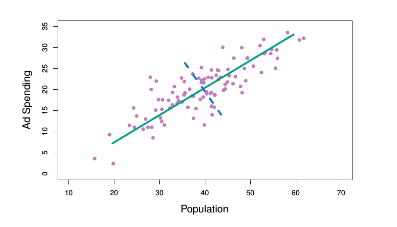

### PCA ejemplo

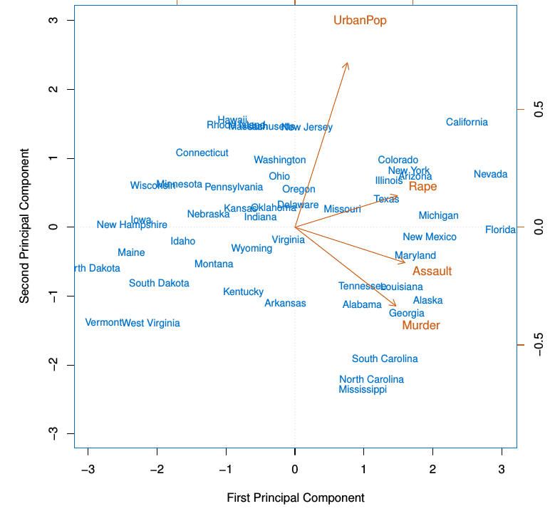

### Proporción de la varianza explicada.

> La varianza total se define como la suma de las varianzas de las variables originales.  
> Las suma de las varianzas explicadas por cada componente principal debe ser igual a la varianza total.

### Proporción de la varianza explicada.

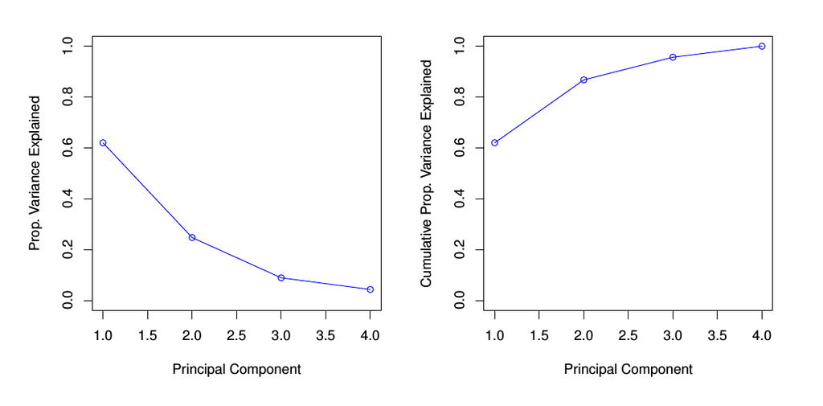

¿cuantos componentes principales retener?

### Análisis de Agrupamiento

- Refiere a diversas técnicas cuyo objetivo es encontrar subgrupos (*clusters*) en los datos.
- las observaciones dentro de un grupo deben ser más similares entre sí que observaciones de grupos diferentes.
- Requiere definir qué significa *similar* o *diferente*.

### Métodos de agrupamiento.

> En *K-means* las observaciones se agrupan en un número prefijado de clusters.  
> En el *agrupamiento jerárquico* no sabemos en cuantos clusters se agruparan los datos. El resultado es un dendrograma.

### K-means

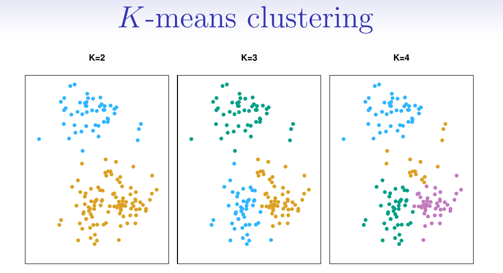

### Algoritmo

1. Asignar al azar un número de 1 a K a cada una de las observaciones. Este servirá como indicador inicial de su pertenencia a una cluster.
2. Iterar hasta que la reasignación del cluster se detenga:
- Para cada uno de los K clusters computar el centroide.
- Asignar cada observación al cluster cuyo centroide esté más cerca.

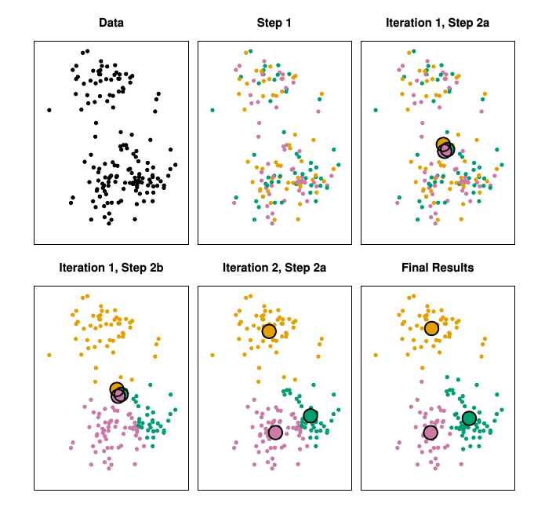

### Agrupamiento Jerárquico

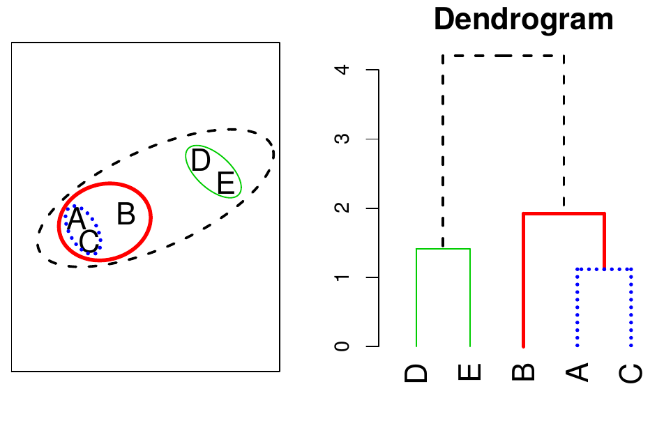

### Algoritmo

1. Comenzar con cada punto siendo su propio cluster.
2. Identificar los dos clusters más cercanos y unirlos.
3. Repetir.
4. Finalizar cuando todos los puntos sean un solo cluster.

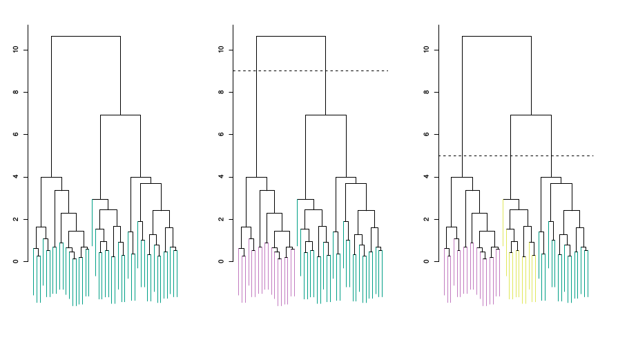